# Pràctica 6

Lucas Poveda

2023-05-10

```r
library(analogue);library(readr); library(FactoMineR)
bcn2019 <- as.data.frame(read_table2("MunicBcn2019_districtes.txt",col_names = FALSE))
distr <- as.vector(bcn2019[,1])
bcn0 <- as.matrix(bcn2019[-1])
rownames(bcn0) <- distr
dim(bcn0)
```

```
## [1] 10 30
```

```r
# tallem i definim "altres" = candidatures amb pocs vots, a partir col 17
altres <- apply(bcn0[,17:30],1,sum)
bcn0 <- data.frame(bcn0[,1:16],altres)
names(bcn0) <- c("Elecs","Votants", "ab","n","Val","b","erc","bec","psc","cs","jts","pp","cup","bcp","vox","pcm","alt")
# comprovem:
all.equal(apply(bcn0[,c(6:17)],1,sum),bcn0[,5],check.attributes=F) # V`alid=blancs+ vots.candidatures (exclou: abs i nuls)
```

```
## [1] TRUE
```

```r
all.equal(bcn0[,5]+bcn0[,4], bcn0[,2], check.attributes=FALSE) # "Votants"=valids+nuls (exclou: abs)
```

```
## [1] TRUE
```

```r
all.equal(bcn0[,2]+bcn0[,3], bcn0[,1], check.attributes=FALSE) # electors=votants+abs
```

```
## [1] TRUE
```

```r
# eliminem:
# "Elecs", "Votants" i "Val" perqu`e s´on sumes parcials, i mantenim la resta:
bcn <- bcn0[,-c(1,2,5)]
```

```r
N <- bcn
npp <- sum(N) # nombre de casos
nip <- apply(bcn, 1, sum) # totals files
npj <- apply(bcn, 2, sum) # totals columnes
tbcn<- cbind(bcn, nip) # N i totals files afegits
tbcn<- rbind(tbcn, c(npj,npp)) # ... i totals columnes afegits
```

Per operar no s’usa la matriu amb els totals afegits, sin´o la de recomptes purs: N (en aquest cas ´es bcn).

1. Imposa que N sigui de classe matriu, per operar. Calcula la matriu de proporcions (freq. relatives del total) i guarda-les en l’objecte P.

```r
N<-as.matrix(N)
P<-N/npp
```

2. Marginals: Calcula i guarda el vector r que cont´e les masses de les columnes i ´es el perfil mitj`a de fila: r = (p+1, . . . , p+p), Fes el mateix amb el vector c que cont´e les masses de les files i ´es el perfil columna mitj`a: c = (p1+, . . . , pn+), Mostra els vectors r i c

```r
r<-apply(P,2,sum)
c<-apply(P,1,sum)
```

3. Calcula la matriu de perfils fila i guarda’ls en una matriu R : s´on les proporcions de vots als partits, condicionats a cada districte. Indicacio: Comprova que totes les files de la matriu R sumen 1.

```r
Dci<-diag(1/c)
R<-Dci%*%P
apply(R, 1, sum)
```

```
##  [1] 1 1 1 1 1 1 1 1 1 1
```

4. Calcula an`alogament la matriu C de perfils columna [ C = P D−1 r ]. Comprova les sumes

```r
Dri<-diag(1/r)
C<-P%*%Dri
apply(C, 2, sum)
```

```
##  [1] 1 1 1 1 1 1 1 1 1 1 1 1 1 1
```

5. Fes una funci´o dr(N,i,h) tal que, donada la matriu de recomptes, calculi la dist`ancia khi-quadrat entre dues files i, h concretes.

```r
dr<-function(N, i, h){
  npp<-sum(N)
  P<-N/npp
  r<-apply(N,2,sum)
  c<-apply(N,1,sum)
  Dci<-diag(1/c)
  R<-Dci%*%P
  Ri<-R[i,]
  Rh<-R[h,]
  d2X2<-(Ri-Rh)^2
  d2x2<-d2X2/r
  d2x2<-sum(d2x2)
  dx2<-sqrt(d2x2)
  print(dx2)
}
```

6. Aplica la funci´o dr() a calcular la dist`ancia entre NB i StA, i entre NB i SSG. Interpreta-ho. NB és la filera 8 StA es la filera 9 SSG es la filera 5

```r
dr(N, 8, 9)
```

```
## [1] 2.275827e-10
```

```r
dr(N, 8, 5)
```

```
## [1] 5.3771e-10
```

Podem dir que la distancia xi2 dels vots de Nou Barris i Sant Andreu es menor que la distancia entre els vots de Noy Barris i Sant Gerbasi

7. Aplica la funci´o dr() a calcular la dist`ancia entre: erc i vox, i entre erc i cup. Interpreta-ho.

Com que la funció esta dissenyada per operar per files pero els partits es troben a les columnes, el que fem es transposar la matriu.

ER es a la columna 4 Vox es a la columna 12 cup es a la columna 10

```r
dr(t(N), 4, 12)
```

```
## [1] 3.179699e-10
```

```r
dr(t(N), 4, 10)
```

```
## [1] 1.564175e-10
```

Podem dir que la distancia entre ER y Vox es major que entre ER i la cup

8. Fes una funci´o dchi(N) que calculi tota la matriu de distancies khi-quadrat entre tots els perfils fila d’una matriu de recomptes N = (nij ). La funci´o dchi() ha de donar una llista amb: la matriu de dist`ancies D = (dχ2 (i, h))i,h, el valor de l’estad´ıstic U i p-valor del test khi-quadrat

```r
dchi<-function(N,dig=2){
  n<-nrow(N)
  p<-ncol(N)
  P<- as.matrix(N/sum(N))
  nip <- apply(N, 1, sum)
  npj <- apply(N, 2, sum)
  npp <- sum(N)
  c<-nip/npp
  r<-npj/npp
  R<-diag(1/c)%*%P
  T<-R%*%diag(1/sqrt(r))
  B<-T%*%t(T)
  b<-diag(B)
  out.b<-outer(b,b,FUN = "+")
  D2<--2*B+out.b
  D<-sqrt(D2)
  ccol<-matrix(c,ncol=1,byrow = T)
  rrow<-matrix(r,nrow=1,byrow=T)
  Z<-diag(1/sqrt(c))%*%(P-ccol%*%rrow)%*%diag(1/sqrt(r))
  U<-npp*sum(diag(Z%*%t(Z)))
  d<-(n-1)*(p-1)
  pval<-pchisq(U,d,lower.tail = F)
  list(val.U=U,gl=d,dchi=round(D,dig), pval=pval)
}
```

9. Aplica la funci´o dchi(), amb 3 d´ıgits, per calcular la matriu de dist`ancies khi-quadrat dels districtes de BCN segons les municipals de 2019. Quina ´es la parella de districtes amb perfils m´es diferents segons els vots i aquesta dist`ancia. El test: Es significatiu? Com ´ s’interpreta?

```r
dchi(N,dig=3)
```

```
## $val.U
## [1] 60011.36
##
## $gl
## [1] 117
##
## $dchi
##        [,1]  [,2]  [,3]  [,4]  [,5]  [,6]  [,7]  [,8]  [,9] [,10]
##  [1,] 0.000 0.421 0.244 0.565 0.692 0.456 0.254 0.265 0.309 0.304
##  [2,] 0.421 0.000 0.221 0.242 0.414 0.166 0.231 0.457 0.232 0.227
##  [3,] 0.244 0.221 0.000 0.395 0.563 0.270 0.055 0.283 0.090 0.088
##  [4,] 0.565 0.242 0.395 0.000 0.202 0.389 0.379 0.528 0.379 0.370
##  [5,] 0.692 0.414 0.563 0.202 0.000 0.547 0.545 0.657 0.553 0.542
##  [6,] 0.456 0.166 0.270 0.389 0.547 0.000 0.299 0.541 0.297 0.298
##  [7,] 0.254 0.231 0.055 0.379 0.545 0.299 0.000 0.248 0.081 0.074
##  [8,] 0.265 0.457 0.283 0.528 0.657 0.541 0.248 0.000 0.278 0.272
##  [9,] 0.309 0.232 0.090 0.379 0.553 0.297 0.081 0.278 0.000 0.023
## [10,] 0.304 0.227 0.088 0.370 0.542 0.298 0.074 0.272 0.023 0.000
##
## $pval
## [1] 0
```

10. Calcula la mateixa matriu de dist`ancies amb la funci´o distance() del paquet analogue, especificant el tipus de dist`ancia amb l’argument method=“chi.distance”.

```r
library(analogue)
distance(N,method="chi.distance")
```

```
##            CV       Eix         SM        LC       SSG        Gr         HG
## CV  0.0000000 0.4205458 0.24387477 0.5652106 0.6919817 0.4557217 0.25368899
## Eix 0.4205458 0.0000000 0.22120944 0.2417523 0.4140817 0.1659512 0.23059554
## SM  0.2438748 0.2212094 0.00000000 0.3947962 0.5626292 0.2701704 0.05529549
## LC  0.5652106 0.2417523 0.39479620 0.0000000 0.2018834 0.3893245 0.37936716
## SSG 0.6919817 0.4140817 0.56262923 0.2018834 0.0000000 0.5473386 0.54525299
## Gr  0.4557217 0.1659512 0.27017044 0.3893245 0.5473386 0.0000000 0.29866230
## HG  0.2536890 0.2305955 0.05529549 0.3793672 0.5452530 0.2986623 0.00000000
## NB  0.2648184 0.4565276 0.28321429 0.5283362 0.6565994 0.5405643 0.24818271
## StA 0.3092630 0.2319136 0.09012991 0.3792488 0.5529877 0.2966153 0.08097760
## StM 0.3041875 0.2271559 0.08762529 0.3698568 0.5415704 0.2979262 0.07363266
##            NB        StA        StM
## CV  0.2648184 0.30926303 0.30418747
## Eix 0.4565276 0.23191357 0.22715590
## SM  0.2832143 0.09012991 0.08762529
## LC  0.5283362 0.37924879 0.36985676
## SSG 0.6565994 0.55298767 0.54157043
## Gr  0.5405643 0.29661526 0.29792619
## HG  0.2481827 0.08097760 0.07363266
## NB  0.0000000 0.27790191 0.27224304
## StA 0.2779019 0.00000000 0.02343551
## StM 0.2722430 0.02343551 0.00000000
## attr(,"method")
## [1] "chi.distance"
## attr(,"class")
## [1] "distance" "matrix"
## attr(,"type")
## [1] "symmetric"
```

11. Aplica ara la funci´o (CA) del paquet FactoMineR. Remarca: Aquesta funci´o fa l’an`alisi de correspond`encies en la qual s’analitzen perfils fila entre s´ı, perfils columna entre s´ı i la correspond`encia files-columnes. L’an`alisi de la correspond`encia es basa en la dist`ancia khi-quadrat i la in`ercia que resulta de multiplicar dist`ancia al quadrat d’una fila al perfil fila mitja per la massa de la fila

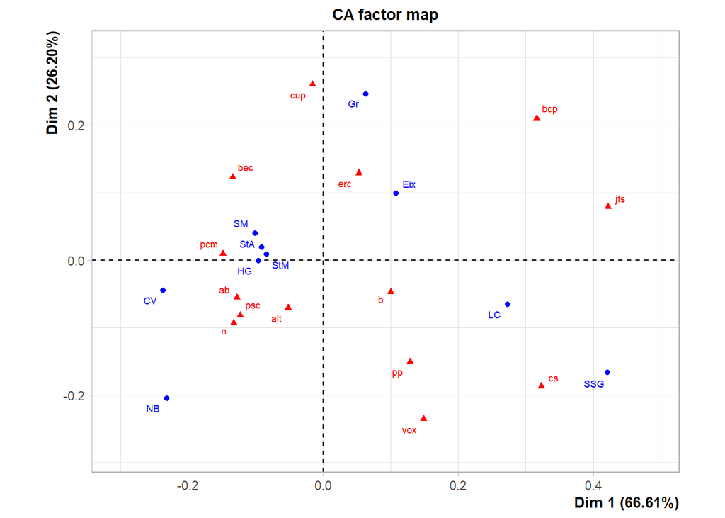

```r
require(FactoMineR)
###?CA
bcn.CA<-CA(bcn,ncp=3,graph=F)
par(mfrow=c(1,1))
plot(bcn.CA,cex=.6)
```

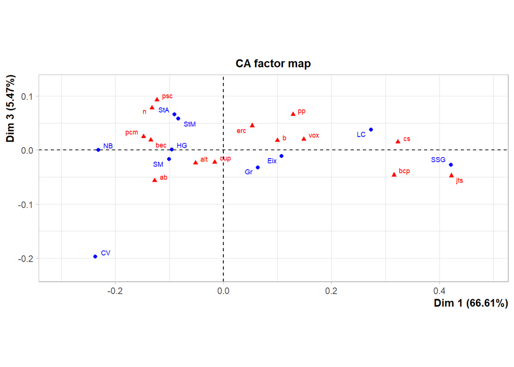

```r
plot(bcn.CA,axes=c(1,3),cex=.6)
```

```r
#
bcn.CA$row$coord
```

```
##           Dim 1         Dim 2         Dim 3
## CV  -0.23684683 -0.0446307731 -0.1973890331
## Eix  0.10783988  0.0986655249 -0.0112929437
## SM  -0.10085476  0.0399519967 -0.0164933426
## LC   0.27338770 -0.0655575502  0.0376912943
## SSG  0.42140225 -0.1664751867 -0.0270572739
## Gr   0.06367742  0.2460371311 -0.0319447002
## HG  -0.09584046 -0.0005884195  0.0009206597
## NB  -0.23159862 -0.2043844601  0.0003308063
## StA -0.09065768  0.0188761764  0.0664500666
## StM -0.08335792  0.0089900658  0.0585367361
```

```r
bcn.CA$row$cos2
```

```
##          Dim 1        Dim 2        Dim 3
## CV  0.56902323 2.020522e-02 3.952218e-01
## Eix 0.52054666 4.357443e-01 5.708410e-03
## SM  0.80952990 1.270331e-01 2.164998e-02
## LC  0.90650999 5.212668e-02 1.723045e-02
## SSG 0.85945904 1.341314e-01 3.543232e-03
## Gr  0.06025014 8.994738e-01 1.516299e-02
## HG  0.93490778 3.524074e-05 8.627187e-05
## NB  0.55436100 4.317342e-01 1.131014e-06
## StA 0.60681543 2.630725e-02 3.260155e-01
## StM 0.63016135 7.329659e-03 3.107528e-01
```

```r
apply(bcn.CA$row$cos2,1,sum) ## qualitat repre 2D
```

```
##        CV       Eix        SM        LC       SSG        Gr        HG        NB
## 0.9844503 0.9619994 0.9582130 0.9758671 0.9971337 0.9748869 0.9350293 0.9860963
##       StA       StM
## 0.9591382 0.9482438
```

```r
iner<-bcn.CA$row$inertia
names(iner)<-rownames(bcn)
iner_perc<-100*iner/sum(iner)
bcn.CA$row$contrib
```

```
##          Dim 1        Dim 2        Dim 3
## CV   6.8656352  0.619731931 5.811350e+01
## Eix  5.3940868 11.478349717 7.208732e-01
## SM   3.2316955  1.289151785 1.053272e+00
## LC  11.5632297  1.690270060 2.678482e+00
## SSG 47.9929875 19.040246781 2.411224e+00
## Gr   0.8938183 33.921041501 2.741331e+00
## HG   2.9161540  0.000279432 3.279415e-03
## NB  15.9742816 31.625295423 3.971753e-04
## StA  2.2671814  0.249858763 1.484408e+01
## StM  2.9009299  0.085774607 1.743356e+01
```

```r
## idem per a columnes ....... !! Per exemple:
apply(bcn.CA$col$cos2,1,sum) ## qualitat repre 2D
```

```
##        ab         n         b       erc       bec       psc        cs       jts
## 0.9984563 0.8769400 0.5909878 0.9450845 0.9824764 0.9849775 0.9899719 0.9956224
##        pp       cup       bcp       vox       pcm       alt
## 0.9432653 0.9217063 0.9824676 0.9460374 0.9114820 0.6648466
```

Interpreta la gr`afica.

12. Repeteix el procediment amb la funci´o CA per`o fent que ara l’abstenci´o i els vots nuls i blancs siguin columnes suplement`aries. De vegades, per comparar amb el resultat anterior pot fer falta canviar el signe de les coordenades ((recorda que el signe ´es arbitrari)).